# Clustering

Romanova

17 декабря 2018 г

# 1 Информация о данных

Данные являются результатом химического анализа красных вин, выращенных в одном и том же регионе Италии, но полученных из трех разных сортов. Переменные – различные химические показатели.

1. Cultivar сорт винограда, качественный признак
   2. Alcohol процент содержания алкоголя
   3. Ash осадок
   4. Alcalinity of ash щелочность осадка
   5. Total phenols общее содержание фенолов
   6. Flavanoids флаваноиды
   7. Color intensity интенсивность цвета
2. Hue оттенок
   9. OD280/OD315 of diluted wines показатель разведенности
   10. Proline пролин

количество индивидов в каждой группе:

1. 58
2. 68
3. 48

Всего индивидов: 174.

Первым делом рассмотрим matrx-plot, расскрашенный в соответствии с сортом винограда. Красным цветом отображается сорт barolo,зеленым – grignolino, синим – barbera.

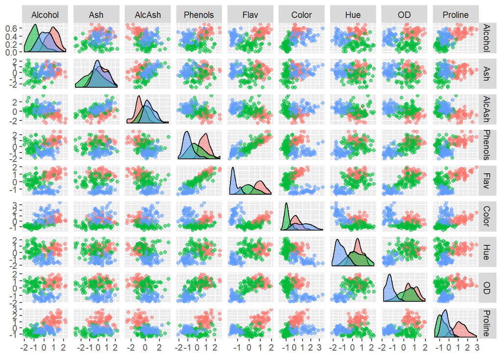

```r
ggpairs(wine.active,aes(colour = as.factor(wine.cultivar), alpha = 0.4), upper = list(continuous = "points", combo =
  "facethist", discrete = "facetbar", na = "na"))
```

Группы ощутимо различаются, поэтому надеемся, что методы кластеризации смогут их более менее правильно разделить.

# 2 Кластеризация

## 2.1 Иерархический анализ

Матрица расстояний:

```r
m<-dist(scale(wine.active))
```

Будем использовать метод слияния Уорда, где в качестве расстояния между кластерами берётся прирост суммы квадратов расстояний индивидов до центра кластера, получаемого в результате их объединения

```r
wine.hc <- hclust(m, method = "ward.D2")
```

В плане интерпретации дендрограмма в данном случае не сможет сильно помочь, так как индивиды, во-первых, не персонализованы, во-вторых, их многовато для такой картинки. Однако мы ее построим для того, чтобы визуально оценить количество кластеров.

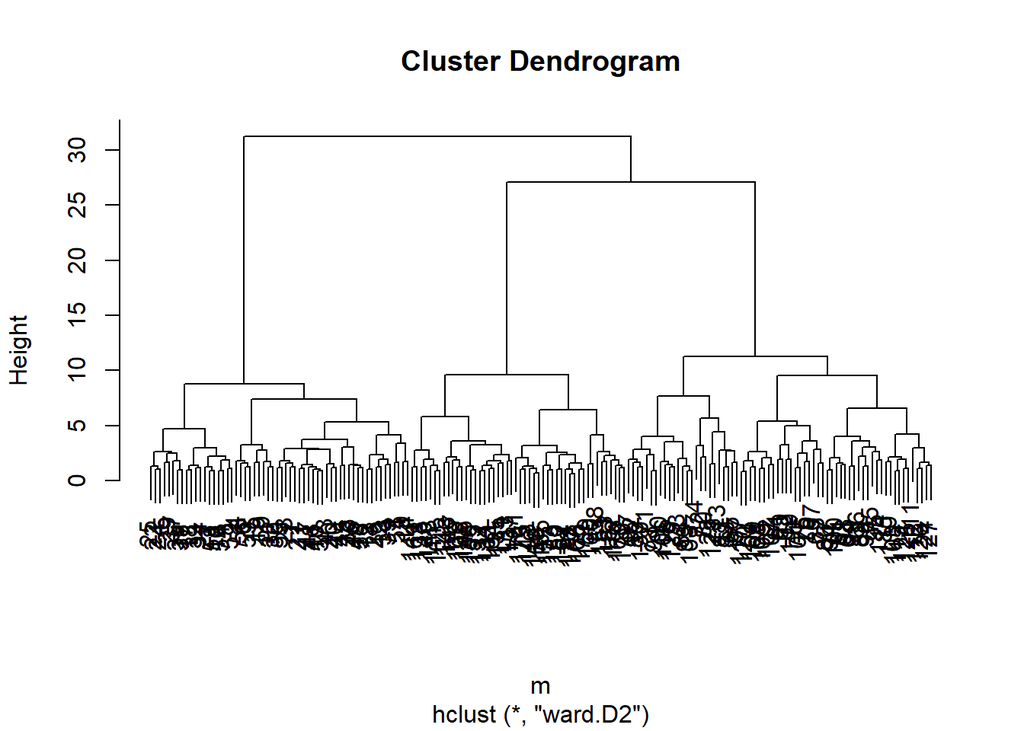

```r
plot(wine.hc)
```

Судя по картинке, наиболее правдоподобный вариант – выделять 3 кластера. Этот вывод соответствует реальности, так как в дейсвительности у нас тоже 3 класса.

Сравним с действительностью:

```r
table(wine.cultivar,cutree(wine.hc, k = 3))
```

```
##
## wine.cultivar  1  2  3
##    barolo     58  0  0
##    grignolino  0 68  0
##    barbera     0  0 48
```

Идеально.

Вместо метода Уорда можно использовать и другие методы, например, “Single link” (метод ближайшего соседа).

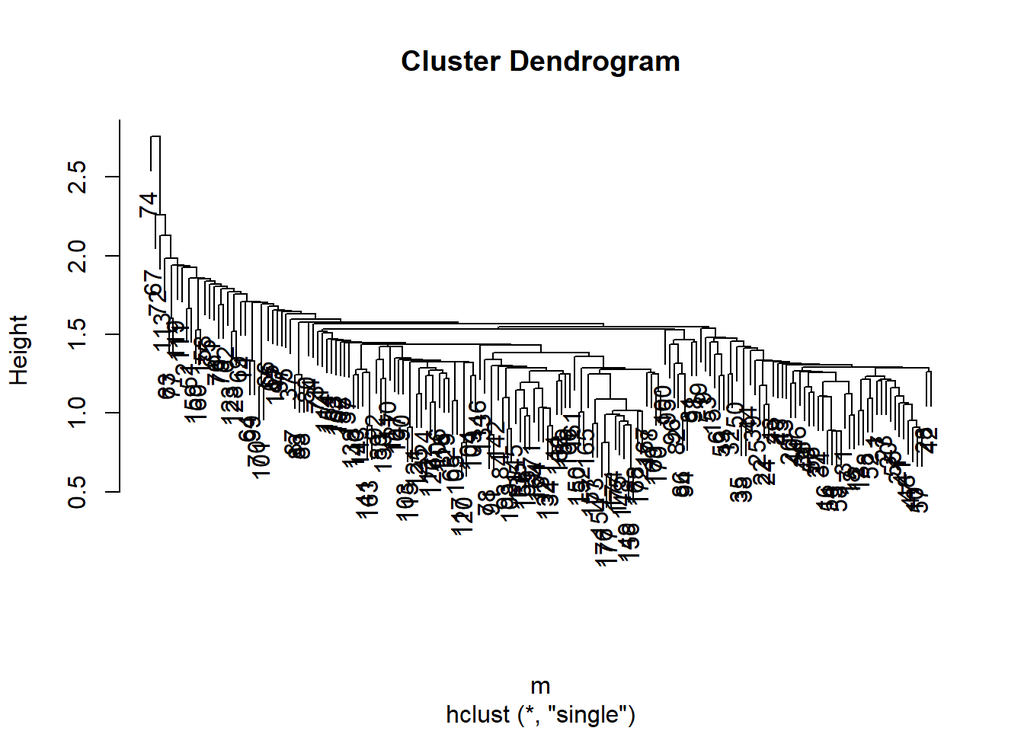

```r
wine.hc2 <- hclust(m, method = "single")
plot(wine.hc2)
```

```r
table(wine.cultivar,cutree(wine.hc2, k = 3))
```

```
##
## wine.cultivar  1  2  3
##    barolo     58  0  0
##    grignolino 66  1  1
##    barbera    48  0  0
```

```r
which(cutree(wine.hc2, k = 3)==c(2,3))
```

```
## 67 74
## 65 72
```

Этот метод нам явно не подходит. Два наблюдения, которые на самом деле являются граничными в группах, приняты за отдельные кластеры, а все остальное – за один большой кластер.

## 2.2 Gaussian mixture models

Часто к хорошему результату приводит предположение, что данные есть смесь нормальных распределений. Тогда можно использовать метод максимального правдоподобия и EM-алгоритм для нахождения максимума правдоподобия.

### 2.2.1 Кластеризация полного набора данных

#### 2.2.1.1 Выбор модели

Для выбора модели, наиболее соответствующей нашим данным, будем использовать информационные критерии.

Байесовский информационный критерий BIC:

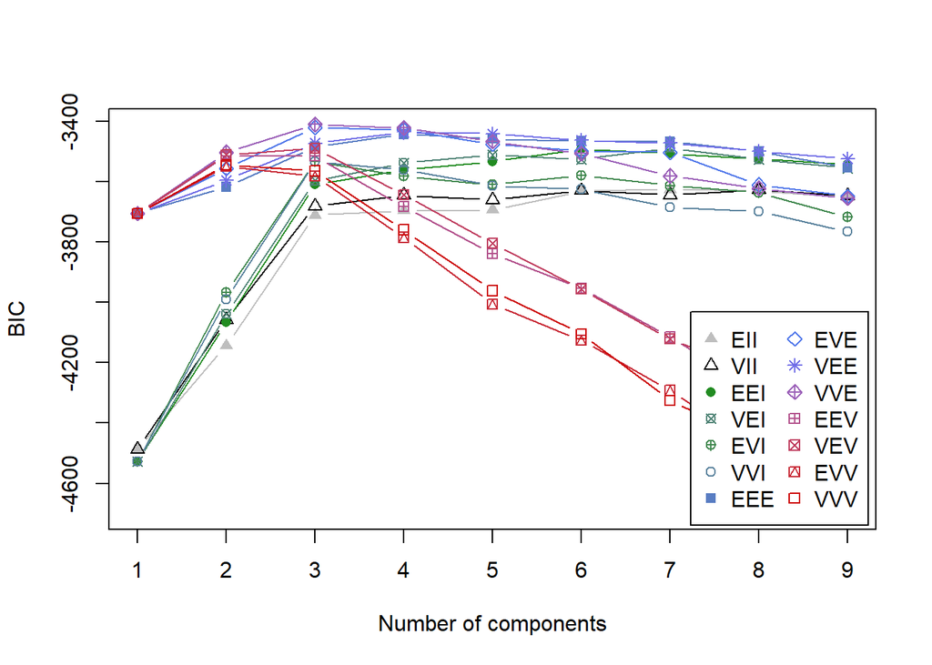

```r
BIC <- mclustBIC(wine.active)
plot(BIC)
```

То, что кластера будет три – это точно. Но нужно решить, какую модель ковариационных матриц мы выберем. Три наилучшии модели по BIC:

```r
summary(BIC)
```

```
## Best BIC values:
##              VVE,3        EVE,3       VVE,4
## BIC      -3409.997 -3419.675002 -3421.32180
## BIC diff     0.000    -9.677782   -11.32458
```

Итак, получили модели VVE (3), EVE(3), VVE(4). VVE(4) сразу отбрасываем, так как эта модель хуже, чем VVE(3), но явно имеет большее число параметров. Первые же две модели есть смысл сравнить.

Число параметров в модели VVE(3) равно (первая скобка – ковариационная матрица, вторая – компоненты смеси, третья – средние)
$$(d(d-1)/2+(d-1)k +k)+(k-1)+kd
=
92.$$

```r
Mclust(wine.active, modelNames = "VVE",G=3)$df
```

```
## [1] 92
```

В модели EVE(3):
$$(d(d-1)/2+(d-1)k+1)+(k-1)+kd
=
90.$$

```r
Mclust(wine.active, modelNames = "EVE",G=3)$df
```

```
## [1] 90
```

Таким образом, у наилучшей модели не намного (на два) больше параметров, чем у следующей, поэтому останавливаем выбор на первой (наилучшей) модели VVE(3). Однако параметров все же очень много (из-за того, что у нас большое d=9), поэтому нужно будет рассматривать варианты понижения размерности.

Критерий ICL также предлагает использовать эту модель.

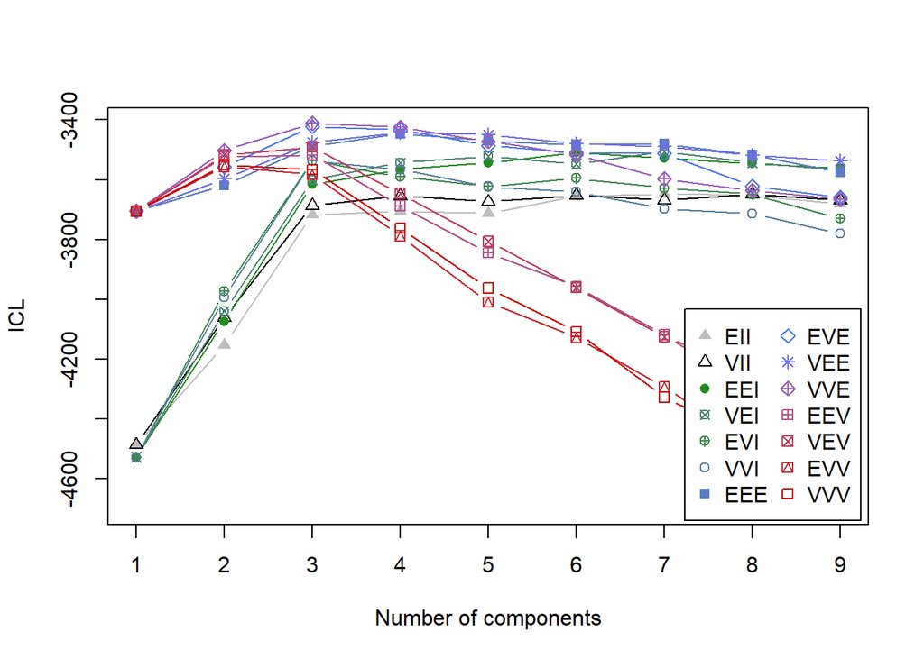

```r
ICL<-mclustICL(wine.active)
plot(ICL)
```

```r
summary(ICL)
```

```
## Best ICL values:
##              VVE,3       EVE,3       VVE,4
## ICL      -3411.436 -3421.87641 -3424.37231
## ICL diff     0.000   -10.44029   -12.93618
```

#### 2.2.1.2 Кластеризация

(На самом деле тоже не совсем полного, мы исходно выкинули переменные, которы вносили совсем небольшой вклад в канонические переменные).

Проведем кластеризацию

```r
wine.mclust<-Mclust(wine.active, x=BIC)
summary(wine.mclust)
```

```
## ----------------------------------------------------
## Gaussian finite mixture model fitted by EM algorithm
## ----------------------------------------------------
##
## Mclust VVE (ellipsoidal, equal orientation) model with 3 components:
##
##  log.likelihood   n df       BIC       ICL
##       -1467.682 174 92 -3409.997 -3411.436
##
## Clustering table:
##  1  2  3
## 56 67 51
```

В пространстве первых двух главных компонент:

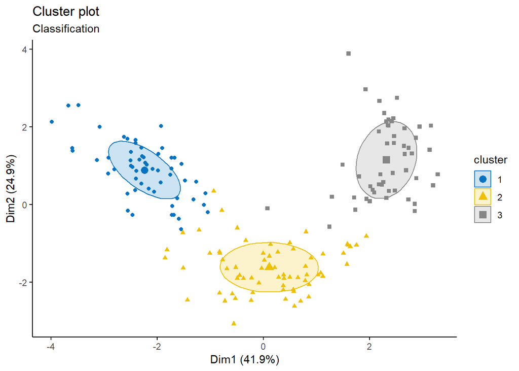

```r
fviz_mclust(wine.mclust, "classification", geom = "point",
            pointsize = 1.5, palette = "jco")
```

Проверка:

```r
table(wine.cultivar,wine.mclust$classification)
```

```
##
## wine.cultivar  1  2  3
##    barolo     56  2  0
##    grignolino  0 65  3
##    barbera     0  0 48
```

Пять неправильно определенных наблюдений.

На следующем графике размер точек пропорционален мере их неопределенности.

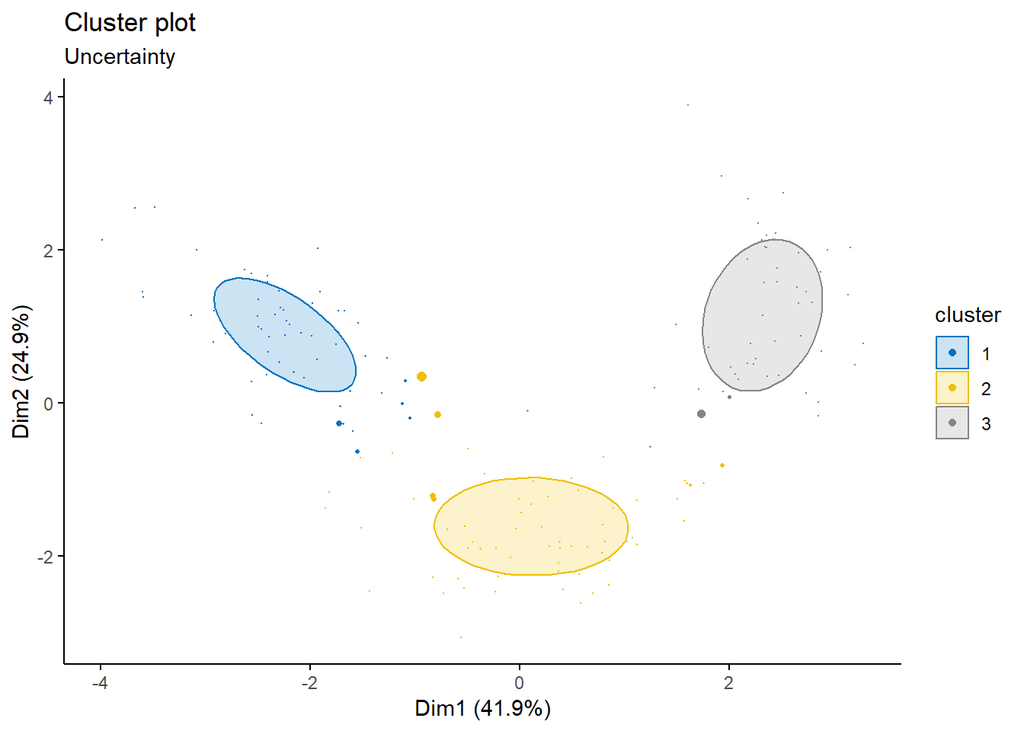

```r
fviz_mclust(wine.mclust, "uncertainty", palette = "jco")
```

### 2.2.2 Кластеризация с меньшим числом параметров

Проведем анализ главных компонент.

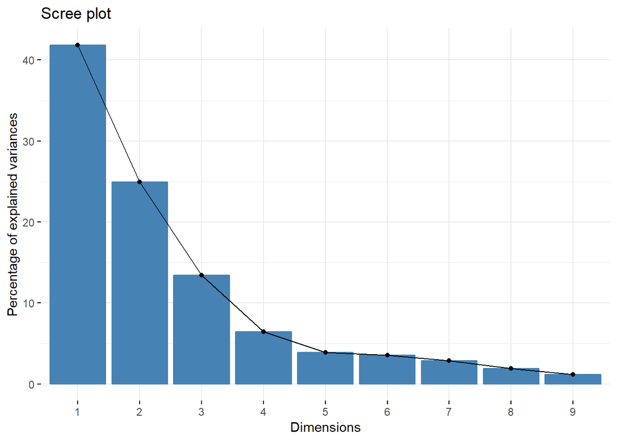

```r
wine.pca<-dudi.pca(wine.active,nf=9,scannf = FALSE)
fviz_eig(wine.pca)
```

```r
get_eigenvalue(wine.pca)
```

```
##       eigenvalue variance.percent cumulative.variance.percent
## Dim.1  3.7673655        41.859617                    41.85962
## Dim.2  2.2434133        24.926815                    66.78643
## Dim.3  1.2084515        13.427239                    80.21367
## Dim.4  0.5784575         6.427305                    86.64098
## Dim.5  0.3482326         3.869251                    90.51023
## Dim.6  0.3174496         3.527217                    94.03745
## Dim.7  0.2604145         2.893494                    96.93094
## Dim.8  0.1726197         1.917997                    98.84894
## Dim.9  0.1035958         1.151064                   100.00000
```

Оставим 3 главные компоненты, объясняющие около 80% дисперсии.

```r
wine.pca$c1
```

```
##                  CS1         CS2         CS3        CS4         CS5
## Alcohol  0.205775326 -0.52043743  0.10245236  0.1111236  0.68644215
## Ash     -0.002775878 -0.32081681 -0.72881425  0.2257147 -0.37188763
## AlcAsh  -0.315189413  0.04022379 -0.61027032 -0.1851350  0.48692202
## Phenols  0.445823961 -0.04353195 -0.15064314 -0.4680568 -0.12679897
## Flav     0.479751398  0.03803591 -0.09873083 -0.2604174 -0.06918656
## Color   -0.097263314 -0.59102267  0.13550157 -0.2166256 -0.05762562
## Hue      0.347329919  0.28872757 -0.11795900  0.6261752  0.20598869
## OD       0.423992019  0.21749853 -0.14070957 -0.2444933  0.21778980
## Proline  0.345711698 -0.37587861  0.03725741  0.3416666 -0.19837967
##                 CS6         CS7         CS8          CS9
## Alcohol -0.24779473 -0.27740258 -0.23320325  0.003930691
## Ash     -0.26313518 -0.32066837  0.06737350  0.006603826
## AlcAsh   0.28048613  0.40718390 -0.07455069 -0.072185893
## Phenols  0.30893645 -0.11642989 -0.35232345  0.555308899
## Flav     0.14075678 -0.07529931 -0.10625248 -0.805771691
## Color    0.46355504 -0.05724761  0.59504589 -0.019591595
## Hue      0.50831051 -0.19361877  0.20681177  0.094437268
## OD      -0.44908638  0.17635054  0.62165131  0.163365201
## Proline -0.02212587  0.75055309 -0.12960237  0.033222399
```

Биплот:

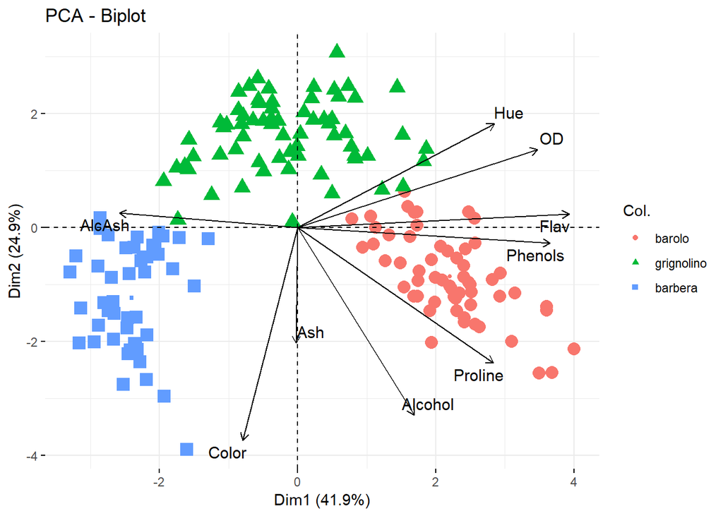

```r
fviz_pca_biplot(wine.pca, repel = TRUE,
                col.var = "black",
                 col.ind = as.factor(wine.cultivar),
                label = "var",
                pointsize = as.factor(wine.cultivar)
                )
```

Первая главная компонента = качество, вторая компонента = специфика сорта grignolino, третья = свойства осадка.

```r
wine.pca<-dudi.pca(wine.active,nf=3,scannf = FALSE)
wine.new<-wine.pca$li
```

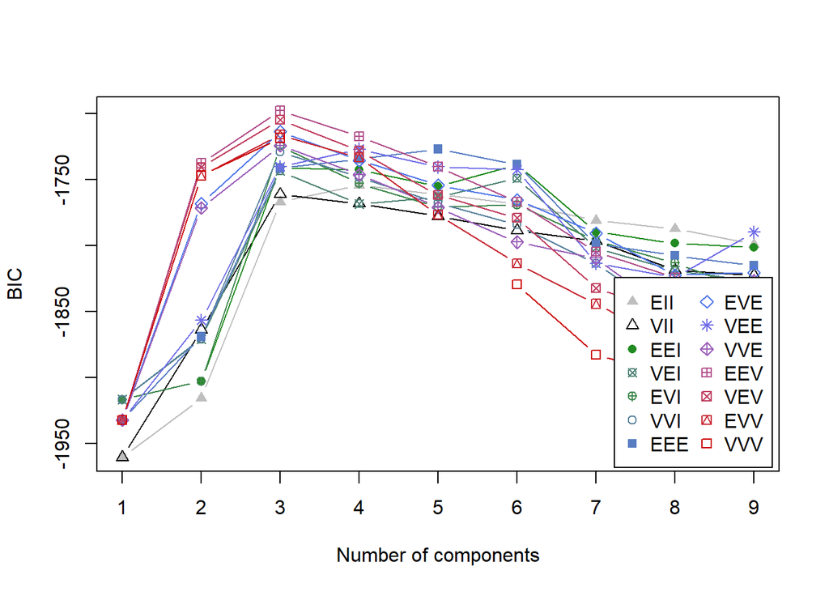

```r
BIC <- mclustBIC(wine.new)
plot(BIC)
```

```r
summary(BIC)
```

```
## Best BIC values:
##              EEV,3        VEV,3       EVE,3
## BIC      -1697.872 -1704.749219 -1713.69543
## BIC diff     0.000    -6.877248   -15.82346
```

```r
Mclust(wine.new, modelNames = "EEV",G=3)$df
```

```
## [1] 23
```

Выбрали модель EEV(3) с 23 параметрами.

```r
wine.new.mclust<-Mclust(wine.new,x=BIC)
summary(wine.new.mclust,parameters=TRUE)
```

```
## ----------------------------------------------------
## Gaussian finite mixture model fitted by EM algorithm
## ----------------------------------------------------
##
## Mclust EEV (ellipsoidal, equal volume and shape) model with 3 components:
##
##  log.likelihood   n df       BIC       ICL
##       -789.6068 174 23 -1697.872 -1707.967
##
## Clustering table:
##  1  2  3
## 60 60 54
##
## Mixing probabilities:
##         1         2         3
## 0.3596377 0.3334094 0.3069530
##
## Means:
##              [,1]       [,2]       [,3]
## Axis1  2.07897668 -0.1012225 -2.3258605
## Axis2 -0.73358506  1.7438930 -1.0347040
## Axis3  0.03885121 -0.2317777  0.2062351
##
## Variances:
## [,,1]
##            Axis1       Axis2      Axis3
## Axis1  0.8253071 -0.60030025 0.18509762
## Axis2 -0.6003002  0.85500198 0.03252576
## Axis3  0.1850976  0.03252576 0.75297108
## [,,2]
##             Axis1       Axis2      Axis3
## Axis1  0.78772374 -0.01022744 0.07774611
## Axis2 -0.01022744  0.24200151 0.23360932
## Axis3  0.07774611  0.23360932 1.40355489
## [,,3]
##            Axis1     Axis2      Axis3
## Axis1 0.22110570 0.1595202 0.02359127
## Axis2 0.15952023 1.2324004 0.30888698
## Axis3 0.02359127 0.3088870 0.97977405
```

Кружочки кластеризованы правильно, треугольники – нет.

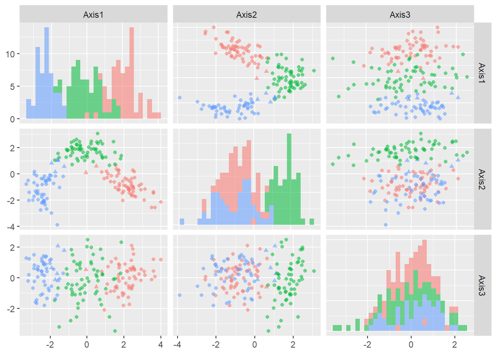

```r
wine.cultivar.plot<-as.factor(wine.cultivar)
levels(wine.cultivar.plot)<-c(1,2,3)
ggpairs(wine.new,aes(colour = as.factor(wine.new.mclust$classification),shape = as.factor(wine.new.mclust$classification!=wine.cultivar.plot),alpha=0.5), upper = list(continuous = "points", combo =
  "facethist", discrete = "facetbar", na = "na"),diag = list(continuous ="barDiag", discrete = "barDiag", na = "naDiag"))
```

Проверка:

```r
table(wine.cultivar,wine.new.mclust$classification)
```

```
##
## wine.cultivar  1  2  3
##    barolo     58  0  0
##    grignolino  2 60  6
##    barbera     0  0 48
```

8 несовпадений с действительностью.

## 2.3 k-means

Для того, чтобы понять, сколько кластеров использовать, можно воспользоваться следующим графиком:

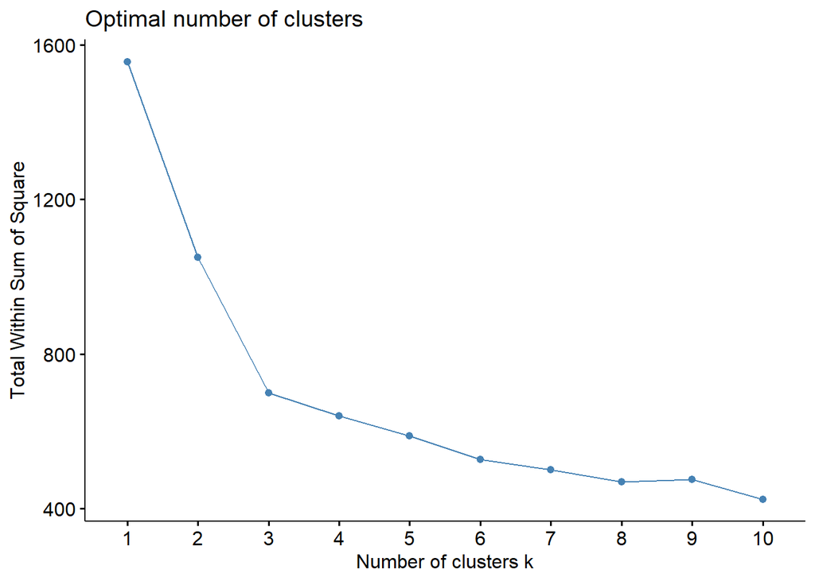

```r
fviz_nbclust(wine.active, kmeans,method =  "wss")
```

на котором изображена зависимость внутригруппового разброса от количества кластеров. Принцип этого графика тот же, что у scree plot. Смотрим, с какого момента добавление нового кластера перестает давать значимое уменьшение суммы квадратов. По этому графику можем сказать, что в нашем случае 3 кластера, что совпадает с действительным количеством классов.

Используем пакет flexclust. Обычный k-means в евклидовой метрике:

```r
km.res <- kcca(wine.active, k=3)
```

В плоскости первых двух гавных компонент:

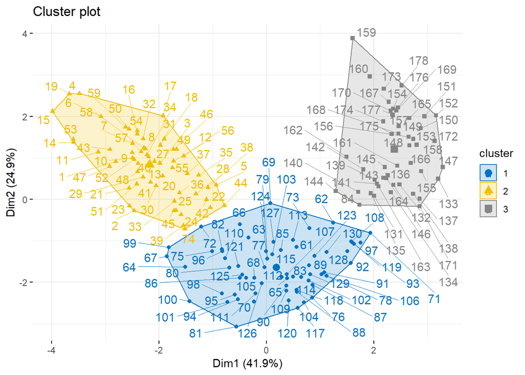

```r
fviz_cluster(as(km.res, "kmeans"), data = wine.active,
             ellipse.type = "convex",
             palette = "jco",
             repel = TRUE,
             ggtheme = theme_minimal())
```

```r
table(wine.cultivar,predict(km.res))
```

```
##
## wine.cultivar  1  2  3
##    barolo      0 58  0
##    grignolino 66  1  1
##    barbera     0  0 48
```

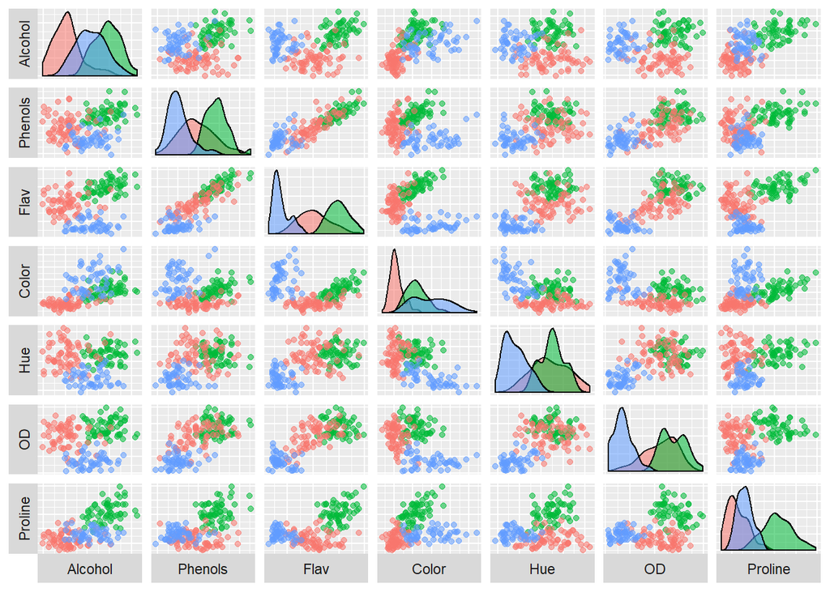

```r
ggpairs(cbind(as.data.frame(wine.active), Cluster=as.factor(predict(km.res))),
        columns = c(1,4,5,6,7,8,9),
        aes(colour=Cluster, alpha=0.5),
        lower=list(continuous="points"),
        upper = list(continuous = "points", combo =
  "facethist", discrete = "facetbar", na = "na"),
        axisLabels="none", switch="both")
```

После того, как мы произвели кластеризацию, полученные результаты можно использовать тем же образом, что и результаты классификации. То есть новые наблюдения причислять к кластеру при помощи уже полученного правила. Пример кластеризующих областей (для двух переменных):

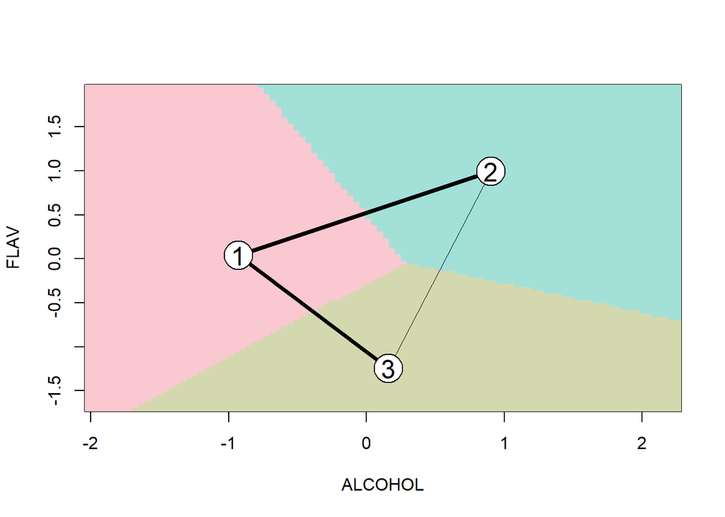

```r
image(km.res,which=c(1,5),xlab="ALCOHOL",ylab="FLAV")
```

Ширина ребра на этом графике пропорциональна сумме теней всех точек, для которых эти два кластера (центры которых соединены ребром) являются самым близким из кластеров и вторым по близости кластером. Под тенью точки понимается отношение удвоенного расстояния от точки до кластера, к которому она определена, и суммы расстояний до самого ближайшего и второго ближайшего кластеров. По смыслу тень – это аналог uncertainty.

k-means в манхетовской метрике:

```r
wine.clust<-cclust(wine.active,k=3,dist="manhattan")
table(wine.cultivar,predict(wine.clust))
```

```
##
## wine.cultivar  1  2  3
##    barolo      0 58  0
##    grignolino  2  3 63
##    barbera    48  0  0
```

Кластеризующая область в манхетовской метрике немного отличается от предыдущей:

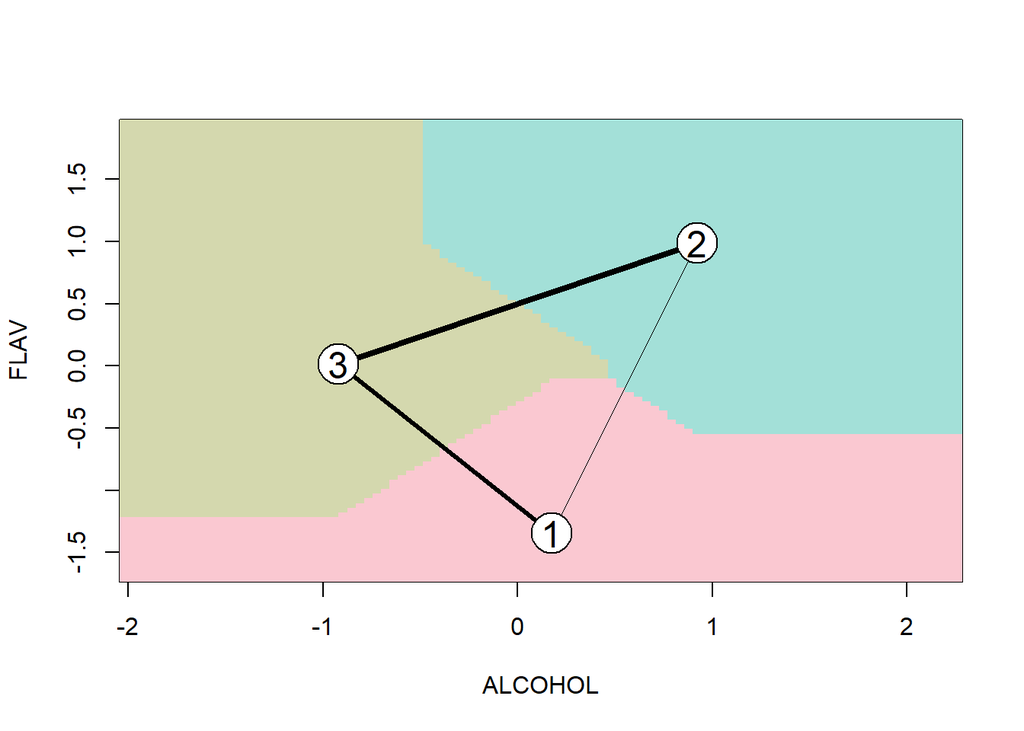

```r
image(wine.clust,which=c(1,5),xlab="ALCOHOL",ylab="FLAV")
```

k-means++:

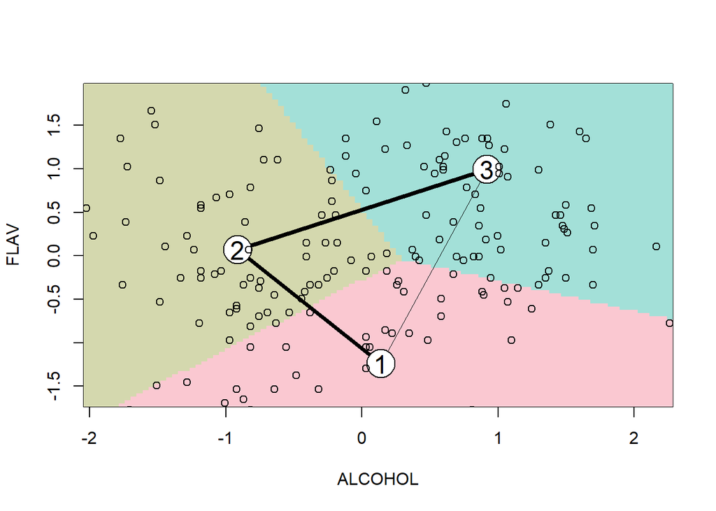

```r
cl2 <- kcca(wine.active, k=3, family=kccaFamily("kmeans"),
control=list(initcent="kmeanspp"))
image(cl2,which=c(1,5),xlab="ALCOHOL",ylab="FLAV")
points(wine.active)
```

```r
table(wine.cultivar,predict(cl2))
```

```
##
## wine.cultivar  1  2  3
##    barolo      0  0 58
##    grignolino  2 66  0
##    barbera    48  0  0
```

Расстояния от наблюдений до центра соответствующего кластера.

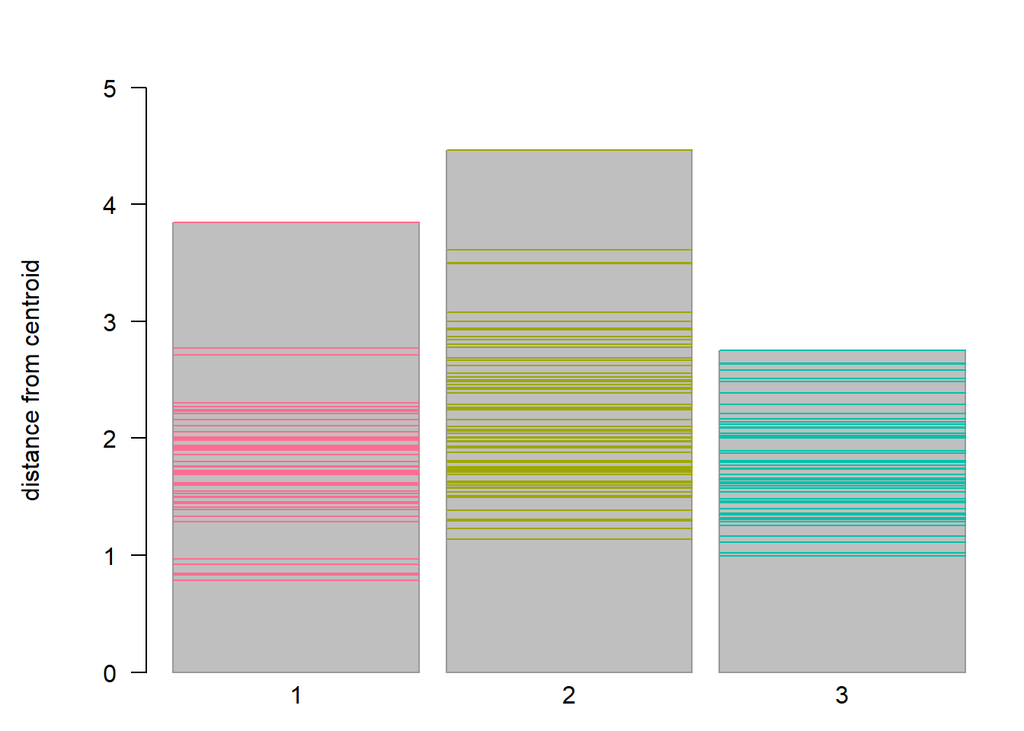

```r
stripes(cl2)
```

Можно рассматривать как аналог partimat:

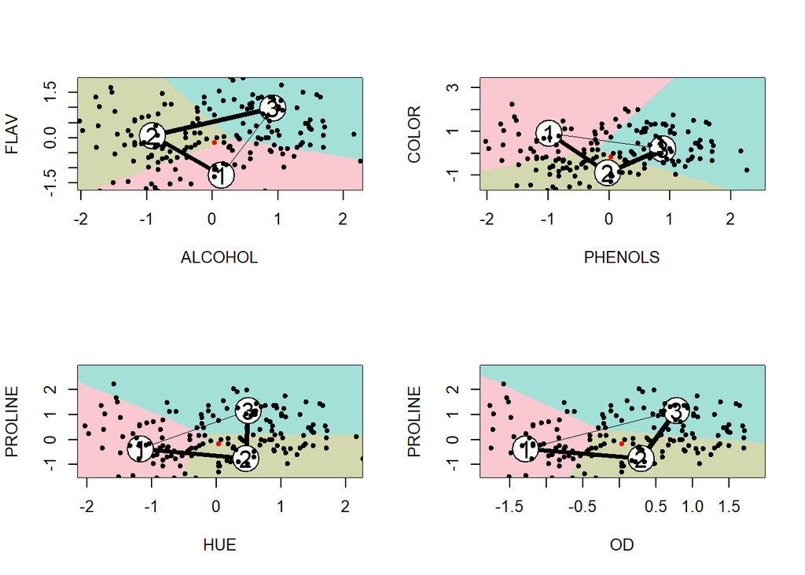

```r
wine.cultivar.plot<-as.factor(wine.cultivar)
levels(wine.cultivar.plot)<-c(3,2,1)

op <- par(mfrow = c(2, 2))
image(cl2,which=c(1,5),xlab="ALCOHOL",ylab="FLAV")
points(wine.active,col=as.factor(as.factor(predict(cl2))!=wine.cultivar.plot),pch=20)
image(cl2,which=c(4,6),xlab="PHENOLS",ylab="COLOR")
points(wine.active,col=as.factor(as.factor(predict(cl2))!=wine.cultivar.plot),pch=20)
image(cl2,which=c(7,9),xlab="HUE",ylab="PROLINE")
points(wine.active,col=as.factor(as.factor(predict(cl2))!=wine.cultivar.plot),pch=20)
image(cl2,which=c(8,9),xlab="OD",ylab="PROLINE")
points(wine.active,col=as.factor(as.factor(predict(cl2))!=wine.cultivar.plot),pch=20)
```

```r
par(op)
```

Таким образом, лучше всех с задачей кластеризации данных Wine справился иерархический анализ (метод Уорда), а Gaussian mixture models – хуже всех. Это может быть связано с тем, что данные по группам у нас на самом деле далеки от нормальных, но при этом в каждой группе состоят действительно похожие между собой индивиды, значительно отличающиеся от двух других групп, поэтому более простые методы иерархического анализа и методы типа k-means справляются с задачей лучше.